# Lab 3

Mitch Morrison, Kyle Kolodziej, Sam Yassien, Brian Pattison

# Business Understanding

Our dataset on video game sales from kaggle (https://www.kaggle.com/rush4ratio/video-game-sales-with-ratings) contains data about its critic and user scores, the platform it is being released on, the developer and publisher of the game, and their sales in different reigons worldwide. For our classification task, we plan on using our dataset to predict game sales (in units, not dollars) into multiple different ranges. Since the range at which sales for video game units vary so largely, we chose to separate our classification groups in a way that allowed us to best balance the amount of video games in each category. See the visualizations below for a better explanation of why we needed to cut our sales categories this way.

We intend on using this data to forecast unit sales of video games based on the attributes listed above. This does not require real-time forecasting because in order to have a proper forecasting model the user will need to collect user and critic scores as well as basic information about the game. Additionally, sales forecasts take place over months, not seconds, reducing the need for immediate results.

## Data Preparation

```python
#imports
import pandas as pd
import numpy as np
import seaborn as sns
import matplotlib
import matplotlib.pyplot as plt
import warnings
warnings.filterwarnings('ignore')
```

```python
df = pd.read_csv('../../Video_game_dataset.csv')
df.head()
```

|  | Name | Platform | Year_of_Release | Genre | Publisher | NA_Sales | EU_Sales | JP_Sales | Other_Sales | Global_Sales | Critic_Score | Critic_Count | User_Score | User_Count | Developer | Rating |
| --- | --- | --- | --- | --- | --- | --- | --- | --- | --- | --- | --- | --- | --- | --- | --- | --- |
| 0 | Wii Sports | Wii | 2006.0 | Sports | Nintendo | 41.36 | 28.96 | 3.77 | 8.45 | 82.53 | 76.0 | 51.0 | 8 | 322.0 | Nintendo | E |
| 1 | Super Mario Bros. | NES | 1985.0 | Platform | Nintendo | 29.08 | 3.58 | 6.81 | 0.77 | 40.24 | NaN | NaN | NaN | NaN | NaN | NaN |
| 2 | Mario Kart Wii | Wii | 2008.0 | Racing | Nintendo | 15.68 | 12.76 | 3.79 | 3.29 | 35.52 | 82.0 | 73.0 | 8.3 | 709.0 | Nintendo | E |
| 3 | Wii Sports Resort | Wii | 2009.0 | Sports | Nintendo | 15.61 | 10.93 | 3.28 | 2.95 | 32.77 | 80.0 | 73.0 | 8 | 192.0 | Nintendo | E |
| 4 | Pokemon Red/Pokemon Blue | GB | 1996.0 | Role-Playing | Nintendo | 11.27 | 8.89 | 10.22 | 1.00 | 31.37 | NaN | NaN | NaN | NaN | NaN | NaN |

```python
df.info()
```

```
<class 'pandas.core.frame.DataFrame'>
RangeIndex: 16719 entries, 0 to 16718
Data columns (total 16 columns):
 #   Column           Non-Null Count  Dtype
---  ------           --------------  -----
 0   Name             16717 non-null  object
 1   Platform         16719 non-null  object
 2   Year_of_Release  16450 non-null  float64
 3   Genre            16717 non-null  object
 4   Publisher        16665 non-null  object
 5   NA_Sales         16719 non-null  float64
 6   EU_Sales         16719 non-null  float64
 7   JP_Sales         16719 non-null  float64
 8   Other_Sales      16719 non-null  float64
 9   Global_Sales     16719 non-null  float64
 10  Critic_Score     8137 non-null   float64
 11  Critic_Count     8137 non-null   float64
 12  User_Score       10015 non-null  object
 13  User_Count       7590 non-null   float64
 14  Developer        10096 non-null  object
 15  Rating           9950 non-null   object
dtypes: float64(9), object(7)
memory usage: 2.0+ MB
```

Our dataset has as significant amount of missing data in attributes that we want to use to predict video game sales worldwide. Rather than imputing this data, since the amount of missing data is so large it will serve is better to drop all instances with NA values.

```python
# drop null value instances and reset index
df = df.dropna()
df = df.reset_index(drop=True)
df.info()
```

```
<class 'pandas.core.frame.DataFrame'>
RangeIndex: 6825 entries, 0 to 6824
Data columns (total 16 columns):
 #   Column           Non-Null Count  Dtype
---  ------           --------------  -----
 0   Name             6825 non-null   object
 1   Platform         6825 non-null   object
 2   Year_of_Release  6825 non-null   float64
 3   Genre            6825 non-null   object
 4   Publisher        6825 non-null   object
 5   NA_Sales         6825 non-null   float64
 6   EU_Sales         6825 non-null   float64
 7   JP_Sales         6825 non-null   float64
 8   Other_Sales      6825 non-null   float64
 9   Global_Sales     6825 non-null   float64
 10  Critic_Score     6825 non-null   float64
 11  Critic_Count     6825 non-null   float64
 12  User_Score       6825 non-null   object
 13  User_Count       6825 non-null   float64
 14  Developer        6825 non-null   object
 15  Rating           6825 non-null   object
dtypes: float64(9), object(7)
memory usage: 853.2+ KB
```

We can see that by dropping all the rows with NA values, we now have only around 40% of our initial data. This is still greater than the 1000 instances needed.

```python
# adjust types to properly fit data
df['User_Score'] = df['User_Score'].astype(np.float)
df['Year_of_Release'] = df['Year_of_Release'].astype(np.int)
```

```python
df.info()
```

```
<class 'pandas.core.frame.DataFrame'>
RangeIndex: 6825 entries, 0 to 6824
Data columns (total 16 columns):
 #   Column           Non-Null Count  Dtype
---  ------           --------------  -----
 0   Name             6825 non-null   object
 1   Platform         6825 non-null   object
 2   Year_of_Release  6825 non-null   int64
 3   Genre            6825 non-null   object
 4   Publisher        6825 non-null   object
 5   NA_Sales         6825 non-null   float64
 6   EU_Sales         6825 non-null   float64
 7   JP_Sales         6825 non-null   float64
 8   Other_Sales      6825 non-null   float64
 9   Global_Sales     6825 non-null   float64
 10  Critic_Score     6825 non-null   float64
 11  Critic_Count     6825 non-null   float64
 12  User_Score       6825 non-null   float64
 13  User_Count       6825 non-null   float64
 14  Developer        6825 non-null   object
 15  Rating           6825 non-null   object
dtypes: float64(9), int64(1), object(6)
memory usage: 853.2+ KB
```

```python
# taking a look at our cleaned data
df.head()
```

|  | Name | Platform | Year_of_Release | Genre | Publisher | NA_Sales | EU_Sales | JP_Sales | Other_Sales | Global_Sales | Critic_Score | Critic_Count | User_Score | User_Count | Developer | Rating |
| --- | --- | --- | --- | --- | --- | --- | --- | --- | --- | --- | --- | --- | --- | --- | --- | --- |
| 0 | Wii Sports | Wii | 2006 | Sports | Nintendo | 41.36 | 28.96 | 3.77 | 8.45 | 82.53 | 76.0 | 51.0 | 8.0 | 322.0 | Nintendo | E |
| 1 | Mario Kart Wii | Wii | 2008 | Racing | Nintendo | 15.68 | 12.76 | 3.79 | 3.29 | 35.52 | 82.0 | 73.0 | 8.3 | 709.0 | Nintendo | E |
| 2 | Wii Sports Resort | Wii | 2009 | Sports | Nintendo | 15.61 | 10.93 | 3.28 | 2.95 | 32.77 | 80.0 | 73.0 | 8.0 | 192.0 | Nintendo | E |
| 3 | New Super Mario Bros. | DS | 2006 | Platform | Nintendo | 11.28 | 9.14 | 6.50 | 2.88 | 29.80 | 89.0 | 65.0 | 8.5 | 431.0 | Nintendo | E |
| 4 | Wii Play | Wii | 2006 | Misc | Nintendo | 13.96 | 9.18 | 2.93 | 2.84 | 28.92 | 58.0 | 41.0 | 6.6 | 129.0 | Nintendo | E |

```python
len(df['Name'].unique())
```

```
4377
```

Since there are only 4377 unique game names, this implies that some games exist on multiple consoles or the same game is being released on the same console in different years.

### Taking a look at how we will create classification categories

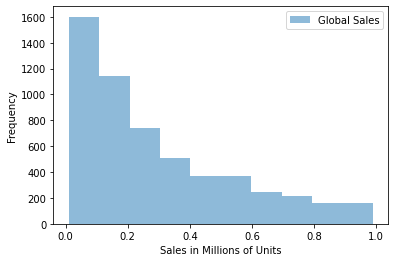

```python
dfLowSales = df[df['Global_Sales'] < 1]
dfLowSales.Global_Sales.plot(kind='hist', alpha=0.5, label="Global Sales")
plt.legend()
plt.xlabel("Sales in Millions of Units")
# plt.yscale("log")
plt.show()
```

We dropped the rows of our data that never reached above 100k video game sales because it was skewing our dataset and classification algorithm to consistently predict that certain games would flop. After dropping these rows, we still ahve about 5000 data points.

```python
index_names = df[ df['Global_Sales'] < .1 ].index
df.drop(index_names, inplace = True)
```

This plot indicates that nearly 4 out of 5 video games in our dataset reach less than 1 million unit sales.

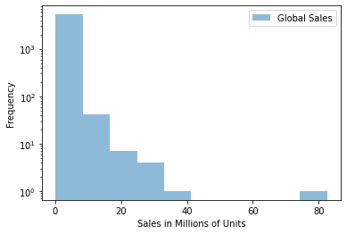

```python
df.Global_Sales.plot(kind='hist', alpha=0.5, label="Global Sales")
plt.legend()
plt.yscale("log")
plt.xlabel("Sales in Millions of Units")
plt.show()
```

We can see that only a handful of games reach above a few million unit sales. Note the y-axis is a log scale, indicating almost all samples fall in the first block of the histogram as we mentioned before. We will split our global sales data into 3 different categories, attempting to see similar frequency of data in our low, medium, and high unit sales categories.

### Cutting our data for our target classification attribute

```python
# LOW = < .3 million sold
# MEDIUM = .3 < X < .75 million sold
# HIGH = > .75 million sold

bins = [0,.3,.75,1e5]
df['Global_Sales_Categories'] = pd.cut(df['Global_Sales'],
                                           bins=bins,
                                           labels=range(3)) # this creates a new variable
```

```
[Text(0, 0, 'Low'), Text(1, 0, 'Medium'), Text(2, 0, 'High')]
```

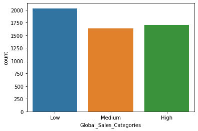

```python
xticks=['Low','Medium','High']
ax = sns.countplot(x="Global_Sales_Categories",data=df)
ax.set_xticklabels(xticks)
```

```python
df.groupby('Global_Sales_Categories').count()
len(df[df['Global_Sales_Categories'].isna()])
```

```
0
```

```python
from sklearn import preprocessing

categorical = ['Platform', 'Genre', 'Publisher', 'Developer', 'Rating']
numData = ['Year_of_Release', 'Critic_Score', 'Critic_Count', 'User_Score', 'User_Count']

numerical = pd.DataFrame()
le = preprocessing.LabelEncoder()

merged = []

for col in categorical:
    name = col + '_encoded'
    numerical[name] = le.fit_transform(df[col])
    merged.append(name)

for col in numData:
    numerical[col] = df[col]
    merged.append(col)

numerical.head()
```

|  | Platform_encoded | Genre_encoded | Publisher_encoded | Developer_encoded | Rating_encoded | Year_of_Release | Critic_Score | Critic_Count | User_Score | User_Count |
| --- | --- | --- | --- | --- | --- | --- | --- | --- | --- | --- |
| 0 | 12 | 10 | 106 | 598 | 1 | 2006 | 76.0 | 51.0 | 8.0 | 322.0 |
| 1 | 12 | 6 | 106 | 598 | 1 | 2008 | 82.0 | 73.0 | 8.3 | 709.0 |
| 2 | 12 | 10 | 106 | 598 | 1 | 2009 | 80.0 | 73.0 | 8.0 | 192.0 |
| 3 | 2 | 4 | 106 | 598 | 1 | 2006 | 89.0 | 65.0 | 8.5 | 431.0 |
| 4 | 12 | 3 | 106 | 598 | 1 | 2006 | 58.0 | 41.0 | 6.6 | 129.0 |

### Test Train Split

```python
from sklearn.model_selection import train_test_split

# X = df[['Platform', 'Year_of_Release', 'Genre', 'Publisher', 'Critic_Score', 'Critic_Count', 'User_Score', 'User_Count', 'Developer', 'Rating']].values
# y = df['Global_Sales_Categories'].values

X = numerical[merged].values
intVals = pd.DataFrame()
intVals['vals'] = df['Global_Sales_Categories'].astype(int)
y = intVals['vals'].values.ravel()

trainX, testX, trainY, testY = train_test_split(X, y, test_size=.2)

print('X train shape:',trainX.shape)
print('X test shape:',testX.shape)
print('Y train shape:',trainY.shape)
print('Y test shape:',testY.shape)
```

```
X train shape: (4295, 10)
X test shape: (1074, 10)
Y train shape: (4295,)
Y test shape: (1074,)
```

Splitting our dataset 80/20 does work. If we had a significant amount of more instances (say 2 million for example) we would not require such a high test train split ratio. With many instances, you can reduce the size of our testing set to a reasonable amount. With a dataset of 2 million instances, a testing set of 200,000 would likely suffice (90/10).

In our case, it is important to have enough training data given our ~5000 instances so an 80/20 split gives us 4000 for training, and 1000 for validation/testing. This is a good split for our dataset.

## One vs All

```python
from numpy.linalg import pinv
from scipy.special import expit

from sklearn.metrics import accuracy_score
# from last time, our logistic regression algorithm is given by (including everything we previously had):
class BinaryLogisticRegression:
    def __init__(self, eta, iterations=20, technique = "steepest", C=0.001, regTerm = "None"):
        self.eta = eta
        self.iters = iterations
        self.technique = technique
        self.C = C
        self.regTerm = regTerm
        # internally we will store the weights as self.w_ to keep with sklearn conventions

    def __str__(self):
        if(hasattr(self,'w_')):
            return 'Binary Logistic Regression Object with coefficients:\n'+ str(self.w_) # is we have trained the object
        else:
            return 'Untrained Binary Logistic Regression Object'

    # convenience, private:
    @staticmethod
    def _add_bias(X):
        return np.hstack((np.ones((X.shape[0],1)),X)) # add bias term

    @staticmethod
    def _sigmoid(theta):
        # increase stability, redefine sigmoid operation
        return expit(theta) #1/(1+np.exp(-theta))

    # vectorized gradient calculation with regularization using L2 Norm
    def _get_gradient(self,X,y):

        if (self.technique == 'stochGrad'):
            idx = int(np.random.rand()*len(y)) # grab random instance
            ydiff = y[idx]-self.predict_proba(X[idx],add_bias=False) # get y difference (now scalar)
            gradient = X[idx] * ydiff[:,np.newaxis] # make ydiff a column vector and multiply through

            gradient = gradient.reshape(self.w_.shape)
            gradient[1:] += -2 * self.w_[1:] * self.C

            return gradient

        elif (self.technique == 'steepest'):
            ydiff = y-self.predict_proba(X,add_bias=False).ravel() # get y difference
            gradient = np.mean(X * ydiff[:,np.newaxis], axis=0) # make ydiff a column vector and multiply through
            return gradient.reshape(self.w_.shape)

        elif (self.technique == 'newton'):
            g = self.predict_proba(X,add_bias=False).ravel() # get sigmoid value for all classes
            hessian = X.T @ np.diag(g*(1-g)) @ X - 2 * self.C # calculate the hessian

            ydiff = y-g # get y difference
            gradient = np.sum(X * ydiff[:,np.newaxis], axis=0) # make ydiff a column vector and multiply through
            gradient = gradient.reshape(self.w_.shape)
            gradient[1:] += -2 * self.w_[1:] * self.C

            return pinv(hessian) @ gradient

    # public:
    def predict_proba(self,X,add_bias=True):
        # add bias term if requested
        Xb = self._add_bias(X) if add_bias else X
        return self._sigmoid(Xb @ self.w_) # return the probability y=1

    def predict(self,X):
        return (self.predict_proba(X)>0.5) #return the actual prediction


    def fit(self, X, y):
        Xb = self._add_bias(X) # add bias term
        num_samples, num_features = Xb.shape

        self.w_ = np.zeros((num_features,1)) # init weight vector to zeros

        # for as many as the max iterations
        for _ in range(self.iters):
            gradient = self._get_gradient(Xb,y)
            self.w_ += gradient*self.eta # multiply by learning rate
            # add because maximizing
            # regularization terms
            if(self.regTerm == 'L1' or self.regTerm == 'L1L2'):
                self.w_[1:] -= self.C*abs(self.w_[1:]) # update not include bias
            if(self.regTerm == 'L2' or self.regTerm == 'L1L2'):
                self.w_[1:] += -2 * self.w_[1:] * self.C # taken from class code
```

```python
class LogisticRegression:
    def __init__(self, eta, iterations=20, technique = "steepest", C=0.0, regTerm = "None"):
        self.eta = eta
        self.iters = iterations
        self.C = C
        self.regTerm = regTerm
        self.technique = technique
        # internally we will store the weights as self.w_ to keep with sklearn conventions

    def __str__(self):
        if(hasattr(self,'w_')):
            return 'MultiClass Logistic Regression Object with coefficients:\n'+ str(self.w_) # is we have trained the object
        else:
            return 'Untrained MultiClass Logistic Regression Object'

    def fit(self,X,y):
        num_samples, num_features = X.shape
        self.unique_ = np.unique(y) # get each unique class value
        num_unique_classes = len(self.unique_)
        self.classifiers_ = [] # will fill this array with binary classifiers

        for i,yval in enumerate(self.unique_): # for each unique value
            y_binary = (y==yval) # create a binary problem
            # train the binary classifier for this class
            blr = BinaryLogisticRegression(self.eta, self.iters, self.technique, self.C, self.regTerm)
            blr.fit(X,y_binary)
            # add the trained classifier to the list
            self.classifiers_.append(blr)

        # save all the weights into one matrix, separate column for each class
        self.w_ = np.hstack([x.w_ for x in self.classifiers_]).T

    def predict_proba(self,X):
        probs = []
        for blr in self.classifiers_:
            probs.append(blr.predict_proba(X)) # get probability for each classifier

        return np.hstack(probs) # make into single matrix

    def predict(self,X):
        return self.unique_[np.argmax(self.predict_proba(X),axis=1)] # take argmax along row
```

```python
def plotHyperparametersVsAccuracy(etas, etaDict, iterations, iterDict, C, cDict):
    fig, (ax1, ax2, ax3) = plt.subplots(1, 3, figsize=(15,5))
    fig.suptitle('Mean Accuracies vs. Hyperparameter')
    etaMeans = [np.mean(accs) for accs in etaDict.values()]
    ax1.plot(etas, etaMeans, 'o')
    ax1.plot(etas, etaMeans)
    ax1.set_xlabel('Eta Value')
    iterMeans = [np.mean(accs) for accs in iterDict.values()]
    ax2.plot(iterations, iterMeans, 'o')
    ax2.plot(iterations, iterMeans)
    ax2.set_xlabel('Iterations')
    cMeans = [np.mean(accs) for accs in cDict.values()]
    ax3.plot(C, cMeans, 'o')
    ax3.plot(C, cMeans)
    ax3.set_xlabel('C value')
    plt.show()

def plotMaxAccuracies(etas, etaDict, iterations, iterDict, C, cDict):
    fig, (ax1, ax2, ax3) = plt.subplots(1, 3, figsize=(15,5))
    fig.suptitle('Max Accuracies Reached vs. Hyperparameter')
    etaMax = [max(accs) for accs in etaDict.values()]
    ax1.plot(etas, etaMax, 'o')
    ax1.set_xlabel('Eta Value')
    iterMax = [max(accs) for accs in iterDict.values()]
    ax2.plot(iterations, iterMax, 'o')
    ax2.set_xlabel('Iterations')
    cMax = [max(accs) for accs in cDict.values()]
    ax3.plot(C, cMax, 'o')
    ax3.set_xlabel('C value')
    plt.show()
```

```python
def bruteForceParameterSearch(etas, iterations, C, regTerms, technique):
    etaDict = {i : [] for i in etas}
    iterDict = {i : [] for i in iterations}
    cDict = {i : [] for i in C}

    highestCombo = (0, (0, 0, 0, 0)) # highest accuracy and corresponding hyperparameters
    for eta in etas :
        for it in iterations :
            for c in C :
                for term in regTerms :
                    lr2 = LogisticRegression(eta=eta, iterations=it, technique=technique, C=c, regTerm=term)
                    lr2.fit(trainX,trainY)
                    yhat = lr2.predict(testX)
                    accuracy = accuracy_score(testY,yhat)
                    etaDict[eta].append(accuracy)
                    iterDict[it].append(accuracy)
                    cDict[c].append(accuracy)
                    if accuracy > highestCombo[0]:
                        highestCombo = (accuracy, (eta, it, c, term))
#                     the print statement below was how we found the best hyper parameters to test on our models
#                     print("Eta:", eta, "Iterations:", it, "C:", c, "RegTerm:", term,'Accuracy of: ', accuracy)

    plotHyperparametersVsAccuracy(etas, etaDict, iterations, iterDict, C, cDict)
    plotMaxAccuracies(etas, etaDict, iterations, iterDict, C, cDict)

    return highestCombo
```

```
This is using the steepest descent technique
============================================
```

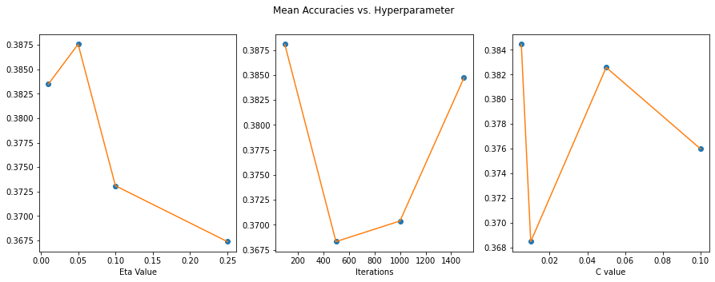

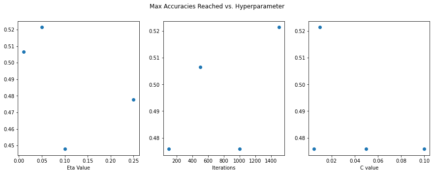

```
(0.521415270018622, (0.05, 1500, 0.01, 'L2'))
```

```python
print("This is using the steepest descent technique")
print("============================================")

etas = [0.01, 0.05, 0.1, .25]
iterations = [100, 500, 1000, 1500]
C = [0.005, 0.01, 0.05, 0.1]
regTerms = ["L1", "L2", "L1L2", "none"]

technique = "steepest"

best = bruteForceParameterSearch(etas, iterations, C, regTerms, technique)
print(best)
```

The charts above displaying the steepest descent accuracies tell us very little about what hyperparameters to use for this kind of model. We see that average accuracy across different etas, iterations, and c values have no clear relationship to improving the accuracy of this model. This makes it very difficult to acheive consistency with this model when employing different parameters. More comparison on this model when we look at scikit learn.

```
This is using Newton's method
============================================
```

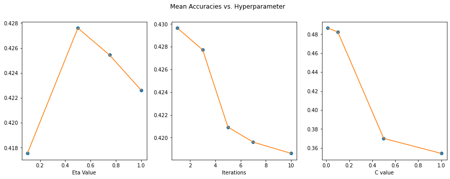

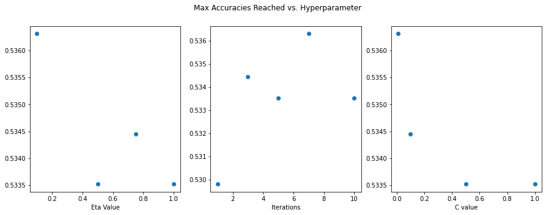

```
(0.5363128491620112, (0.1, 7, 0.01, 'L1'))
```

```python
print("This is using Newton's method")
print("============================================")

etas = [0.1, 0.5, 0.75, 1]
iterations = [1, 3, 5, 7, 10]
C = [0.01, 0.1, 0.5, 1]
regTerms = ["L1", "L2", "L1L2", "none"]
technique = "newton"

best = bruteForceParameterSearch(etas, iterations, C, regTerms, technique)
print(best)
```

```
This is using the stochastic gradient descent technique
============================================
```

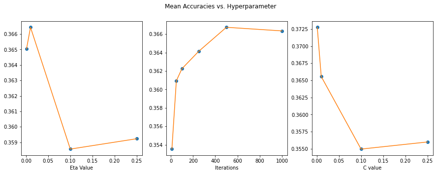

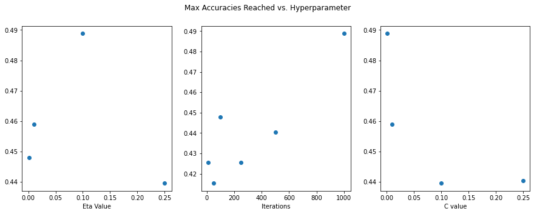

```
(0.4888268156424581, (0.1, 1000, 0.001, 'L1'))
```

```python
print("This is using the stochastic gradient descent technique")
print("============================================")
etas = [0.001, 0.01, 0.1, .25]
iterations = [10, 50, 100, 250, 500, 1000]
C = [0.001, 0.01, 0.1, .25]
regTerms = ["L1", "L2", "L1L2", "none"]
technique = "stochGrad"

best = bruteForceParameterSearch(etas, iterations, C, regTerms, technique)
print(best)
```

In these graphs representing the classification accuracy using stochastic gradient descent we see that it has the lowest average accuracies of all of our models. We also see that the C value used has a large affect on our accuracy, and as C grows the corrections become too large and affect our ability to properly classify the data. For this reason we use lower C values for more consistency. More iterations helped improve the avergae accuracy of the model until it topped out at ~36.6%.

### Is brute force searching for the best hyperparameters bad?

There is no doubt that using a brute force approach in this partiuclar scenario where we are unaware of the best ways to find model parameters meets the goal of helping find the most accurate models. However, this sort of brute force approach would likely not be efficient on models that require more computation or are of higher complexity and likely would not be a useful way to tune hyperparameters in those sorts of models. This sort of "data snooping" by altering the hyperparameters to meet the current test and training dataset likely is a cause of some overfitting to the current dataset. It is likely that with our current dataset our hyperparameters are accurately tuned, but with a new testing dataset it would need to change because the accuracy could fall.

## Comparing our Models to Scikit Learn

```python
from sklearn.linear_model import LogisticRegression as SKLogisticRegression
import time
```

```python
%%time
start = time.time()
lr_sk = SKLogisticRegression(solver='liblinear')
lr_sk.fit(trainX,trainY)
yhat = lr_sk.predict(testX)
print('Accuracy of: ',accuracy_score(testY,yhat))
totalTimeSKL = (time.time() - start) * 1000
```

```
Accuracy of:  0.5279329608938548
CPU times: user 55.1 ms, sys: 2.3 ms, total: 57.4 ms
Wall time: 55.7 ms
```

```python
%%time
# Eta: 1 Iterations: 3 C: 1 RegTerm: none Accuracy of:  ~52
start = time.time()
lr2 = LogisticRegression(1, 3, technique="newton", C = 1, regTerm="None")
lr2.fit(trainX,trainY)
yhat = lr2.predict(testX)
print('Accuracy of: ',accuracy_score(testY,yhat))
totalTimeNewt = (time.time() - start) * 1000
```

```
Accuracy of:  0.5260707635009311
CPU times: user 1.46 s, sys: 1.19 s, total: 2.65 s
Wall time: 691 ms
```

```python
%%time
# Eta: 0.01 Iterations: 100 C: 0.05 RegTerm: L1 Accuracy of:  ~49
start = time.time()
lr2 = LogisticRegression(0.01, 100, technique="steepest", C = 0.05, regTerm="L1")
lr2.fit(trainX,trainY)
yhat = lr2.predict(testX)
print('Accuracy of: ',accuracy_score(testY,yhat))
totalTimeSteep = (time.time() - start) * 1000
```

```
Accuracy of:  0.4813780260707635
CPU times: user 312 ms, sys: 62.7 ms, total: 375 ms
Wall time: 100 ms
```

```python
%%time
#Eta: 0.01 Iterations: 250 C: 0.01 RegTerm: L1 Accuracy of:  ~45
start = time.time()
lr2 = LogisticRegression(0.01, 250, technique="stochGrad", C = 0.01, regTerm="L1")
lr2.fit(trainX,trainY)
yhat = lr2.predict(testX)
print('Accuracy of: ',accuracy_score(testY,yhat))
totalTimeSGD = (time.time() - start) * 1000
```

```
Accuracy of:  0.4581005586592179
CPU times: user 24.3 ms, sys: 2.3 ms, total: 26.6 ms
Wall time: 22.7 ms
```

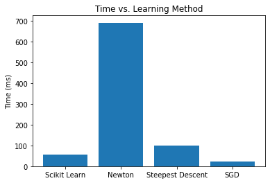

```python
plt.bar(['Scikit Learn', 'Newton', 'Steepest Descent', 'SGD'], [totalTimeSKL, totalTimeNewt, totalTimeSteep, totalTimeSGD])
plt.ylabel('Time (ms)')
plt.title('Time vs. Learning Method')
plt.show()
```

Our much more consistent and accurate model uses Newton's method, but it is far slower (takes 700 ms as opposed to 70 ms for scikit learn. This is because each iteration of newtons method is extremely computationally expensive to calculate the Hessian). Looking at the charts above depicting newtons methods' average accuracy compared to the other models, we see a difference of nearly anywhere from 5-10% better accuracy.

Comparing all of our models to scikit learn, we agree that using the scikit learn implementation is the best option for deployment. This is because it is consistently faster than our models (with exception to some stochastic gradient descent runs) and has acheived very similar accuracy compared to our most accurate method, the newtons method. For this reason, scikit learn implementation is a better choice than using one of our custom models.

## Deployment

Our team would recommend employing the steepest descent model to predict video game sales if the deployement required real time prediciton. However, in the market of video game sales, the additional seconds to minutes to get a more accurate classification is far more important than having nearly real time estimates. After all, video game sales are not instantly sold normally, and instead go through sales lifecycles like many other products. It makes sense to deploy newtons model because it is far more consistent at reaching higher levels of accuracy than our other models (see mean accuracy graph). If it were an option to use the scikit learn implementation, we would use this method because it is more reliably accurate and far faster than newtons method.

One caveot to the model we would choose to deploy is that we do not feel our model is accurate enough for market use. We feel that reaching only 50% accuracy on our model is not sufficient enough to help us accurately predict what range of sales a video game release is likely to reach or garner market interest to buy our model.

## Exceptional Work

We are turing our assignment in one day late and do not expect any credit for this section of the lab. Thank you for the extra day, we really needed it.